# Wstęp do uczenia maszynowego - Projekt 1

## Aleksander Malinowski | Damian Skowroński

### Wprowadzenie

W projekcie używamy zbioru danych [Chess king rook](https://www.apispreadsheets.com/datasets/115), który dotyczy zakończeń gier w szachy w przypadku gdy biała strona ma króla i wieżę, a czarnej pozostał tylko król. Założeniem jest, że obie strony wykonują optymalne ruchy i ruch jest czarnego.

```python
import numpy as np
import pandas as pd
import matplotlib.pyplot as plt
import seaborn as sns
import warnings
warnings.filterwarnings('ignore')

df = pd.read_csv('chess_king_rook_dataset.csv')
df.head()
```

|  | white_king_file | white_king_rank | white_rook_file | white_rook_rank | black_king_file | black_king_rank | result |
| --- | --- | --- | --- | --- | --- | --- | --- |
| 0 | a | 1 | b | 3 | c | 2 | draw |
| 1 | a | 1 | c | 1 | c | 2 | draw |
| 2 | a | 1 | c | 1 | d | 1 | draw |
| 3 | a | 1 | c | 1 | d | 2 | draw |
| 4 | a | 1 | c | 2 | c | 1 | draw |

Jak widać mamy pozycje każdej z trzech figur, a zmienna opisywana *result* mówi o tym, czy gra zakończyła się remisem (poprzez pat, lub przez zbicie wieży), lub w ilu ruchach od danej pozycji gra zakończyła się matem.

Sprawdzenie, czy są wartości "NA":

```python
df.isna().sum()
```

```
white_king_file    0
white_king_rank    0
white_rook_file    0
white_rook_rank    0
black_king_file    0
black_king_rank    0
result             0
dtype: int64
```

Okazuje się, że nie, teraz dokładniejsze sprawdzenie, czy brakujące wartości nie kryją się pod innym oznaczeniem.

```python
for column in df.columns:
    print(column, df[column].unique())
```

```
white_king_file ['a' 'b' 'c' 'd']
white_king_rank [1 2 3 4]
white_rook_file ['b' 'c' 'd' 'e' 'f' 'g' 'h' 'a']
white_rook_rank [3 1 2 4 5 6 7 8]
black_king_file ['c' 'd' 'e' 'f' 'g' 'h' 'a' 'b']
black_king_rank [2 1 3 4 5 6 7 8]
result ['draw' 'zero' 'one' 'two' 'three' 'four' 'five' 'six' 'seven' 'eight'
 'nine' 'ten' 'eleven' 'twelve' 'thirteen' 'fourteen' 'fifteen' 'sixteen']
```

Wszystkie wartości są sensowne dla szachów, czyli w zbiorze danych nie ma brakujących wartości. Wobec tego nie będzie potrzebna imputacja. Co ciekawe, można zauważyć, że pola białego króla ograniczają się do kwadratu 4x4.

### Encoding

Dla zmiennych określających linię na szachownicy, stosujemy *label encoding*. Natomiast dla zmiennej *result* zamienimy tekstowe wartości na liczby, a wartości "draw" tymczasowo przypiszemy wartość -1.

```python
from sklearn.preprocessing import LabelEncoder

def encode_df(dataframe):
    le = LabelEncoder()
    for column in dataframe.columns:
        if 'file' in column:
            dataframe[column] = le.fit_transform(dataframe[column])
            dataframe[column] += 1
    return dataframe

df = encode_df(df)
```

```python
def encode_results(string):
    if string == 'draw':
        string = -1
    elif string == 'zero':
        string = 0
    elif string == 'one':
        string = 1
    elif string == 'two':
        string = 2
    elif string == 'three':
        string = 3
    elif string == 'four':
        string = 4
    elif string == 'five':
        string = 5
    elif string == 'six':
        string = 6
    elif string == 'seven':
        string = 7
    elif string == 'eight':
        string = 8
    elif string == 'nine':
        string = 9
    elif string == 'ten':
        string = 10
    elif string == "eleven":
        string = 11
    elif string == "twelve":
        string = 12
    elif string == "thirteen":
        string = 13
    elif string == "fourteen":
        string = 14
    elif string == "fifteen":
        string = 15
    else:
        string = 16
    return string
df.result = df.result.apply(lambda x: encode_results(x))
df
```

|  | white_king_file | white_king_rank | white_rook_file | white_rook_rank | black_king_file | black_king_rank | result |
| --- | --- | --- | --- | --- | --- | --- | --- |
| 0 | 1 | 1 | 2 | 3 | 3 | 2 | -1 |
| 1 | 1 | 1 | 3 | 1 | 3 | 2 | -1 |
| 2 | 1 | 1 | 3 | 1 | 4 | 1 | -1 |
| 3 | 1 | 1 | 3 | 1 | 4 | 2 | -1 |
| 4 | 1 | 1 | 3 | 2 | 3 | 1 | -1 |
| ... | ... | ... | ... | ... | ... | ... | ... |
| 28051 | 2 | 1 | 7 | 7 | 5 | 5 | 16 |
| 28052 | 2 | 1 | 7 | 7 | 5 | 6 | 16 |
| 28053 | 2 | 1 | 7 | 7 | 5 | 7 | 16 |
| 28054 | 2 | 1 | 7 | 7 | 6 | 5 | 16 |
| 28055 | 2 | 1 | 7 | 7 | 7 | 5 | 16 |

28056 rows × 7 columns

W ten sposób w ramce danych mamy same wartości numeryczne.

### Nowe zmienne

W celu potencjalnie lepszych wyników późniejszego modelu, uznaliśmy, że dobrym pomysłem jest policzenie odległości czarnego króla od krawędzi planszy, odległości króli między sobą, a także odległości czarnego króla od białej wieży. Wybraliśmy takie zmienne, ze względu na naturę osiągnięcia mata w systuacji przedstawionej w zbiorze danych.

```python
def distance(df):
    # dystans czarnego króla od krawędzi
    return min(df['black_king_file'] - 1, 8 - df['black_king_file'], df['black_king_rank'] - 1, 8 - df['black_king_rank'])

df['black_king_dst'] = df.apply(lambda x: distance(x), axis = 1)
```

```python
def blackwhitedistance(df):
    # dystans pomiędzy królami
    return max(abs(df['black_king_file'] - df['white_king_file']),abs(df['black_king_rank'] - df['white_king_rank']))

df['black2white_king_dst'] = df.apply(lambda x: blackwhitedistance(x), axis = 1)
```

```python
print("najmniejsza odległość =",np.min(df.black2white_king_dst),"\nnajwiększa odległość =",np.max(df.black2white_king_dst))
```

```
najmniejsza odległość = 2
największa odległość = 7
```

W trakcie sprawdzania, czy nie wychodzą nam za duże, lub za małe wartości, udało nam się dojść do jeszcze jednego wniosku, mianowicie ponieważ minimalna odległość dwóch króli to 2 - to znaczy, że w zbiorze danych nie ma sprzecznych z grą ustawień.

```python
def black2rookdistance(df):
     # dystans pomiędzy czarnym królem i wieżą
    return max(abs(df['black_king_file'] - df['white_rook_file']),abs(df['black_king_rank'] - df['white_rook_rank']))
df['black2rook_dst'] = df.apply(lambda x: black2rookdistance(x), axis = 1)

def white2rookdistance(df):
     # dystans pomiędzy białym królem i wieżą
    return max(abs(df['white_king_file'] - df['white_rook_file']),abs(df['white_king_rank'] - df['white_rook_rank']))
```

Po dotychczasowych krokach ramka wygląda tak:

```python
df.head()
```

|  | white_king_file | white_king_rank | white_rook_file | white_rook_rank | black_king_file | black_king_rank | result | black_king_dst | black2white_king_dst | black2rook_dst |
| --- | --- | --- | --- | --- | --- | --- | --- | --- | --- | --- |
| 0 | 1 | 1 | 2 | 3 | 3 | 2 | -1 | 1 | 2 | 1 |
| 1 | 1 | 1 | 3 | 1 | 3 | 2 | -1 | 1 | 2 | 1 |
| 2 | 1 | 1 | 3 | 1 | 4 | 1 | -1 | 0 | 3 | 1 |
| 3 | 1 | 1 | 3 | 1 | 4 | 2 | -1 | 1 | 3 | 1 |
| 4 | 1 | 1 | 3 | 2 | 3 | 1 | -1 | 0 | 2 | 1 |

### Podział i EDA

Przed analizą danych dzielimy zbiory na treningowy i walidacyjny, a następnie zapisujemy te dane w plikach csv.

```python
from sklearn.model_selection import train_test_split
def split_data(df):
    feats = [feat for feat in df.columns if feat != 'result']
    X = df[feats]
    y = df['result']
    return X, y
df_train,df_test = train_test_split(df, test_size=0.3, random_state=42, stratify=df.result)
```

```python
df_train.to_csv("training_set.csv")
df_test.to_csv("validation_set.csv")
```

Od tej pory będziemy się zajmować wyłącznie treningowym zbiorem danych.

```python
df = df_train
```

Przeprowadzamy anazlizę jednowymiarową

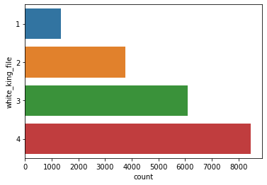

```python
sns.countplot(y = "white_king_file", data = df.sort_values(by = "white_king_file"),orient="h")
```

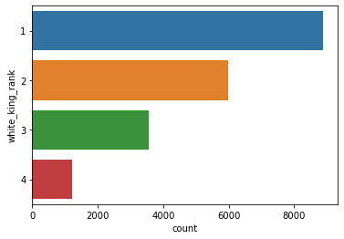

```python
sns.countplot(y = "white_king_rank", data = df.sort_values(by = "white_king_rank"),orient="h")
```

```python
df[["white_king_rank","white_king_file"]].value_counts().reset_index().sort_values(by = ["white_king_rank","white_king_file"]).rename(columns = { 0 : "count"}).reset_index(drop = True)
```

|  | white_king_rank | white_king_file | count |
| --- | --- | --- | --- |
| 0 | 1 | 1 | 1330 |
| 1 | 1 | 2 | 2530 |
| 2 | 1 | 3 | 2540 |
| 3 | 1 | 4 | 2493 |
| 4 | 2 | 2 | 1224 |
| 5 | 2 | 3 | 2358 |
| 6 | 2 | 4 | 2394 |
| 7 | 3 | 3 | 1188 |
| 8 | 3 | 4 | 2357 |
| 9 | 4 | 4 | 1225 |

Z tego widzimy, że król jest ograniczony tylko do takiego trójkąta:

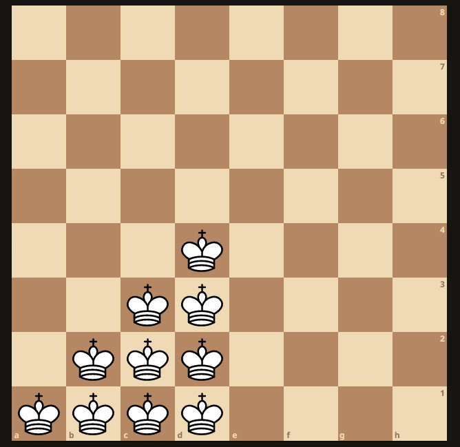

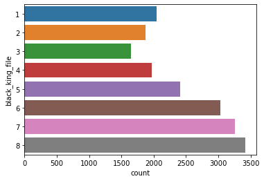

```python
sns.countplot(y = "black_king_file", data = df.sort_values(by = "black_king_file"),orient="h")
```

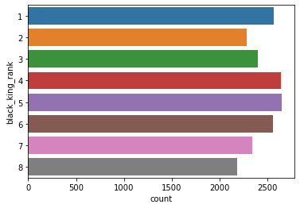

```python
sns.countplot(y = "black_king_rank", data = df.sort_values(by = "black_king_rank"),orient="h")
```

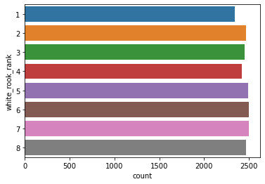

```python
sns.countplot(y = "white_rook_rank", data = df.sort_values(by = "white_rook_rank"),orient="h")
```

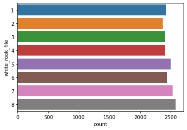

```python
sns.countplot(y = "white_rook_file", data = df.sort_values(by = "white_rook_file"),orient="h")
```

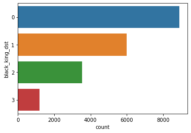

```python
sns.countplot(y = "black_king_dst", data = df.sort_values(by = "black_king_dst"),orient="h")
```

Ma sens w końcu im bliżej środka planszy tym mniej pól o takiej odległości.

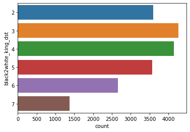

```python
sns.countplot(y = "black2white_king_dst", data = df.sort_values(by = "black2white_king_dst"),orient="h")
```

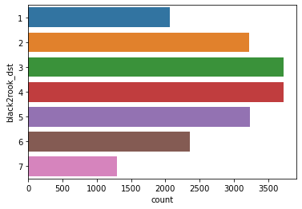

```python
sns.countplot(y = "black2rook_dst", data = df.sort_values(by = "black2rook_dst"),orient="h")
```

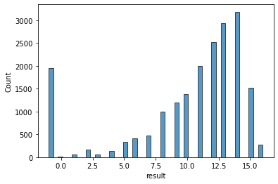

```python
sns.histplot(x = "result", data = df)
```

Widać, że w zbiorze danych zwykle do mata potrzeba było więcej ruchów. Pierwsza kolumna na wykresie oznacza liczbę remisów, których też jest stosunkowo dużo.

Analiza dwuwymiarowa:

```python
df.corr()
```

|  | white_king_file | white_king_rank | white_rook_file | white_rook_rank | black_king_file | black_king_rank | result | black_king_dst | black2white_king_dst | black2rook_dst |
| --- | --- | --- | --- | --- | --- | --- | --- | --- | --- | --- |
| white_king_file | 1.000000 | 0.456087 | -0.009108 | 0.000182 | -0.140401 | 0.105595 | -0.195264 | -0.054697 | -0.297172 | 0.025093 |
| white_king_rank | 0.456087 | 1.000000 | 0.008568 | -0.008044 | 0.097899 | -0.123493 | -0.247554 | -0.095732 | -0.358309 | 0.036792 |
| white_rook_file | -0.009108 | 0.008568 | 1.000000 | -0.008674 | -0.015768 | -0.001490 | -0.056035 | 0.013431 | -0.016254 | -0.132705 |
| white_rook_rank | 0.000182 | -0.008044 | -0.008674 | 1.000000 | 0.004017 | -0.025332 | 0.001758 | -0.008814 | -0.004573 | 0.020399 |
| black_king_file | -0.140401 | 0.097899 | -0.015768 | 0.004017 | 1.000000 | -0.075550 | 0.044304 | -0.069412 | 0.268161 | 0.020694 |
| black_king_rank | 0.105595 | -0.123493 | -0.001490 | -0.025332 | -0.075550 | 1.000000 | 0.216334 | 0.027861 | 0.611104 | -0.022466 |
| result | -0.195264 | -0.247554 | -0.056035 | 0.001758 | 0.044304 | 0.216334 | 1.000000 | 0.230134 | 0.152326 | 0.350126 |
| black_king_dst | -0.054697 | -0.095732 | 0.013431 | -0.008814 | -0.069412 | 0.027861 | 0.230134 | 1.000000 | -0.358527 | -0.322727 |
| black2white_king_dst | -0.297172 | -0.358309 | -0.016254 | -0.004573 | 0.268161 | 0.611104 | 0.152326 | -0.358527 | 1.000000 | 0.124789 |
| black2rook_dst | 0.025093 | 0.036792 | -0.132705 | 0.020399 | 0.020694 | -0.022466 | 0.350126 | -0.322727 | 0.124789 | 1.000000 |

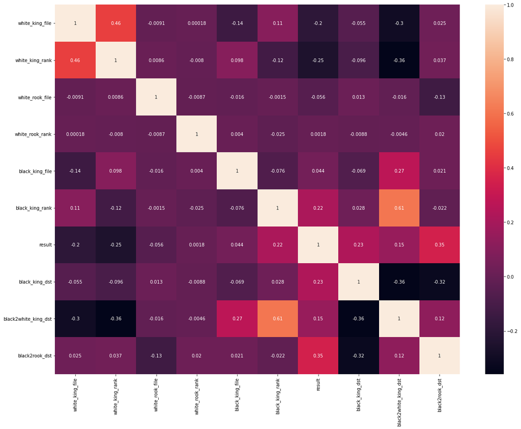

```python
fig, ax = plt.subplots(figsize=(20, 15))
sns.heatmap(df.corr(),annot=True)
```

Z wykresu widać, że żadne zmienne nie mają wystarczająco dużej korelacji, abyśmy musieli je usuwać. Zmienna *result* ma dosyć dobrą korelację z kilkoma zminnymi, między innymi dobre wartości są z kolumnami, które utworzyliśmy. Ciekawym spostrzeżeniem jest różnica w korelacji pomiędzy zmiennymi _black_king*file* i _black_king*rank*, a zmienną *result*. Wygląda na to, że większość graczy woli matować do jednej z poziomych krawędzi planszy.

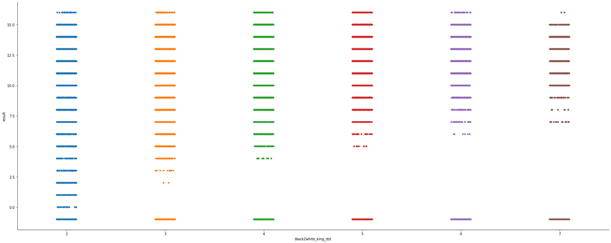

```python
sns.catplot(x="black2white_king_dst", y="result", data=df,height=10,aspect=2.5)
```

Próbowaliśmy zobaczyć jak się ma gęstość ilości ruchów potrzebnych do mata względem odległości pomiędzy królami, ale wykres nie okazał się najlepszy. Jedyne co można zauważyć to, że im większa startowa odległość między królami, tym więcej ruchów potrzeba na mata. Jest to zrozumiałe, poniważ do mata króle powinny być obok siebie.

### Predykcja

Podchodzimy do problemu przewidzenia rezultatu w wykonując następujące kroki:

### 1. Własna klasyfikacja

#### Remisy

Remisy nam bardzo przeszkadzają w dalszej regresji więc postaramy się je przewidzieć w inny sposób i całkowicie je pominąć przy regresji.

Ponieważ zbiór danych teoretycznie przedstawia optymalne ruchy, a przewaga białego nad czarnym jest duża, remis zachodzi zapewne w jednej z dwóch sytuacji:

1. czarny bije białą wieżę
2. stalemate - czarny nie ma gdzie się ruszyć

##### 1. Czarny bije białą wieżę

Taka sytuacja zdaży się w momencie, gdy czarny król jest w odległości od białej wieży równej "1", a biały król jest w odległości od białej wieży większej niż "1". Możemy to zrobić używając stworzonych przez nas zmiennych _white2rook*dst* i _black2rook*dst*

```python
def w2r_rt(df):
    #white to rook distance + rook taken
    df['white2rook_dst'] = df.apply(lambda x: white2rookdistance(x), axis = 1)
    df["rook_taken"] = np.where(
        (df.black2rook_dst == 1) & (df.white2rook_dst != 1),
        1,0)
    return df

df = w2r_rt(df)
```

```python
from sklearn.metrics import confusion_matrix
confusion_matrix(df.rook_taken,df.result.apply(lambda x: 1 if x == -1 else 0))
```

```
array([[17682,     5],
       [    0,  1952]], dtype=int64)
```

Okazuje się, nowa zmienna prawie dokładnie opisuje sytuacje i popełniła tylko kilka błędów, gdy nie znajduje remisu.

##### 2. Stalemate

W tym przypadku wystąpi w następujących sytuacjach:

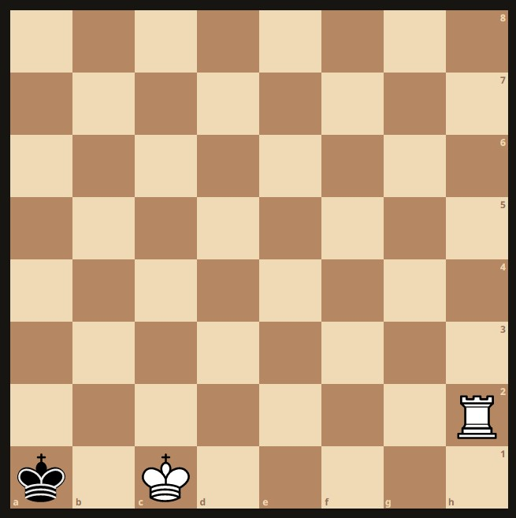

Pierwsza sytuacja wystąpi jeśli wieża jest w dowolnym miejsu oprócz w kolumnie "a" w drugim rzędzie. Również w takiej samej sytuacji, ale dla lustrzanego odbicia wzdłuż diagonali idącej z lewego dolnego rogu do prawego górnego. Oczywiście też podobnie dla każdego rogu.

Inaczej mówiąc jest to sytuacja, gdy jednocześnie:

- czarny król jest na granicy planszy,
- biały król jest w tym samym rzędzie/kolumnie co czarny król
- odległość króli między sobą wynosi $2$
- biała wieża jest przesunięta o odpowiednio jeden rząd/kolumnę od granicy planszy
- biała wieża nie jest w tej samej kolumnie/rzędzie co czarny król, żeby nie mógł jej zbić (ta sytuacja i tak jest remisem, więc nie trzeba tego warunku brać pod uwagę)

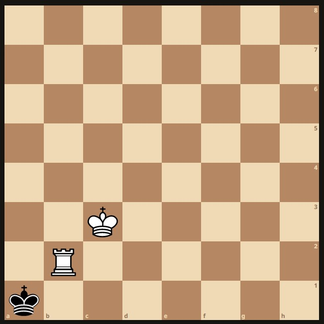

Druga sytuacja wystąpi tylko po 5 razy (w czym 2 znich pokrywają się z pierwszą sytuacją) w każdym rogu. Bo biały król może być na jednym z pięciu możliwych pól obok wieży.

Dzieje się to przy następujących warunkach:

- czarny król jest w samym rogu
- biała wieża jest na diagonali oddalona od czarnego króla o 1
- biały król musi być przy białej wieży (nie jest to ważny warunek, bo jeśli nie jest przy niej to i tak jest remis i wcześniej bierzemy to pod uwagę)

```python
def drawed(df):
    df["is_draw"] = np.where(
        ((df.black2rook_dst == 1) & (df.white2rook_dst != 1)) |      # czarny bije wieze
        ((df.black_king_dst == 0) & (((np.abs(df.black_king_file - df.black_king_rank)) == 0) |  ((np.abs(df.black_king_file - df.black_king_rank)) == 7)) & (df.black2white_king_dst == 2) & (((df.white_king_file == df.black_king_file) & (np.abs(df.white_rook_file - df.black_king_file) == 1)) | ((df.white_king_rank == df.black_king_rank) & (np.abs(df.white_rook_rank - df.black_king_rank) == 1)))) |  # pierwsza sytuacja
        ((df.black_king_dst == 0) & (df.black2rook_dst == 1) & (((np.abs(df.black_king_file - df.black_king_rank)) == 0) |  ((np.abs(df.black_king_file - df.black_king_rank)) == 7)) & (((np.abs(df.white_rook_file - df.white_rook_rank)) == 0) |  ((np.abs(df.white_rook_file - df.white_rook_rank)) == 7))), # druga sytuacja
        1,0)
    return df
df = drawed(df)
```

```python
confusion_matrix(df.is_draw,df.result.apply(lambda x: 1 if x == -1 else 0))
```

```
array([[17682,     0],
       [    0,  1957]], dtype=int64)
```

W ten sposób możemy już przewidzieć każdy ramis/nieremis prawidłowo.

#### 0 ruchów do mata

Wydaje się że można też jednoznacznie powiedzieć, kiedy mat już jest, czyli w zmiennej result jest wartość $0$. Sytuacja wygląda tak:

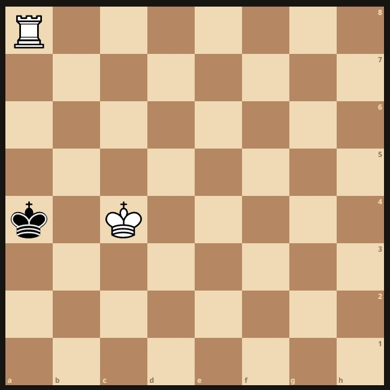

lub rzadziej tak:

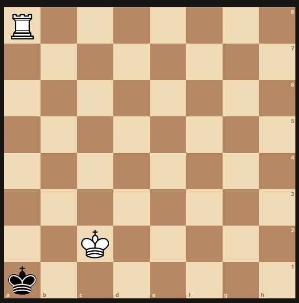

Inaczej można powiedzieć, że jednocześnie:

- czarny król jest na krawędzi planszy
- odległość między królami jest równa 2
- wieża nie jest zbijana (nie ma remisu)
- wieża jest w tej samej kolumnie/rzędzie co czarny król
- biały król jest odpowiednio w tym samym rzędzie/kolunie co czarny król (chyba, że czarny król jest w rogu)

```python
def mated(df):
    df["is_mated"] = np.where(
        (df.black_king_dst == 0) & (df.black2white_king_dst == 2) & (df.is_draw == 0) & ((((df.black_king_file == df.white_rook_file) & (df.black_king_rank == df.white_king_rank) & ((df.black_king_file == 1) | (df.black_king_file == 7)))) | ((df.black_king_rank == df.white_rook_rank) & (df.black_king_file == df.white_king_file) & ((df.black_king_rank == 1) | (df.black_king_rank == 7)))) |
        (df.black_king_dst == 0) & (df.black2white_king_dst == 2) & (df.is_draw == 0) & (((np.abs(df.black_king_file - df.black_king_rank)) == 0) |  ((np.abs(df.black_king_file - df.black_king_rank)) == 7)) & ((((df.black_king_file == df.white_rook_file) & (np.abs(df.black_king_rank - df.white_king_rank) == 1) & ((df.black_king_file == 1) | (df.black_king_file == 7)))) | ((df.black_king_rank == df.white_rook_rank) & (np.abs(df.black_king_file - df.white_king_file) == 1) & ((df.black_king_rank == 1) | (df.black_king_rank == 7)))),
        1,0)
    return df

df = mated(df)
```

```python
confusion_matrix(df.is_mated,df.result.apply(lambda x: 1 if x == 0 else 0))
```

```
array([[19620,     0],
       [    0,    19]], dtype=int64)
```

Macierz mówi, że wyłapaliśmy wszystkie przypadki bez błędów.

### 1 ruch do mata

Można też przewidzieć kiedy zostanie jeden ruch do mata jednak jest to bardziej skomplikowana sytuacja. Poniższy kod będzie działać tylko na tym zbiorze, w którym biały król jest ograniczony do pól w trójkącie w rogu planszy (oczywiście da sie zrobić to mądrzej, żeby działało na całą plansze, ale troche trzeba nad tym posiedzieć). Są to przykładowo następujące sytuacje:

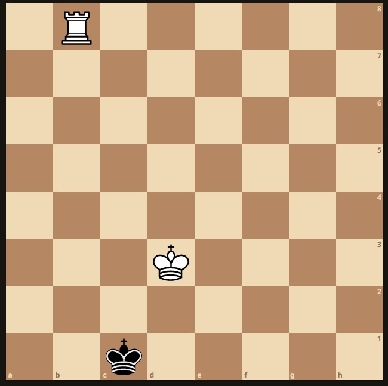

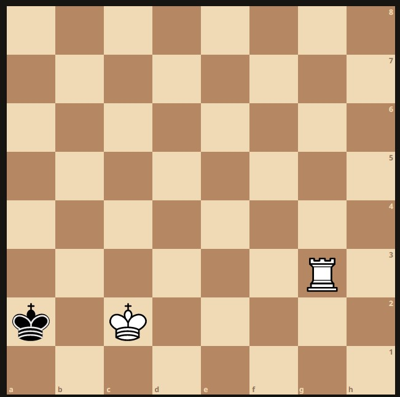

```python
def mated_in1(df):
    df["is_mated1"] = np.where(
        (df.black_king_dst == 0) & (df.rook_taken ==0) & (df.is_mated ==0) & (df.is_draw == 0) & (
            ((df.black_king_rank == 1) & (df.black_king_file == 1) & (df.white_king_file == 3) & (df.white_king_rank == 2) & (df.white_rook_file >= 2) & (df.white_rook_rank > 3)) |
            ((df.white_rook_file == 1) &  (df.black_king_file == 2) & (df.white_king_file == 3) & (df.white_king_rank == 3)) |
            ((df.black_king_file == 1) & (df.black_king_rank == 3) & (df.white_rook_rank == 4) & (df.white_king_file == 3) & (df.white_king_rank == 2)) |
            ((df.black_king_file == 1) & (df.black_king_rank == 2) & (df.white_rook_rank == 3) & (df.white_king_file == 3) & (df.white_king_rank == 1)) |
            ((df.black_king_file == 5) & (df.black_king_rank == 1) & (df.white_rook_file == 6) & (df.white_king_file == 4) & (df.white_king_rank == 3)) |
            ((df.black_king_file == 4) & (df.black_king_rank == 1) & (df.white_rook_file == 5) & (df.white_king_file == 3) & (df.white_king_rank == 3)) |
            ((df.black_king_file == 3) & (df.black_king_rank == 1) & (df.white_rook_file == 2) & (df.white_king_file == 4) & (df.white_king_rank == 3)) |
            ((df.black_king_file == 1) & (df.black_king_rank == 2) & (df.white_rook_rank == 3) & (df.white_king_file == 3) & (df.white_king_rank == 2))
        ),
        1,0
    )
    return df
df_test = mated_in1(df)
```

```python
confusion_matrix(df_test.is_mated1, df.result.apply(lambda x: 1 if x == 1 else 0))
```

```
array([[19584,     0],
       [    0,    55]], dtype=int64)
```

Znowu udało nam się wyłapać wszystkie takie sytuacje

Możliwe, że jeszcze można zrobić tak dla sytuacji, w których wymagane jest więcej ruchów, ale oczywiście oznacza to, że takie sytuacje są bardziej skomplikowane, jest więcej warunków

### 2. Regresja

Regresję wykonujemy w celu dowiedzenia się ile ruchów będzie potrzebne do zamatowania. Wykonywać ją będziemy na części obserwacji, które w poprzednim kroku nie zostały już przewidziane.

```python
def drop_predicted(df):
    # do regresji zostawiamy tylko te wiersze, których nie przewidzieliśmy
    # na początku sortujemy w ten spoosb, aby remisy były na początku, a potem maty, żeby potem łatwiej połączyć ramkę, i nie musiec pamietac o indexach
    df_sorted = df.sort_values(by = ["is_draw","is_mated","is_mated1"], ascending= False).reset_index(drop=True)
    df_draws = df_sorted.drop(index=np.where(df_sorted.is_draw != 1)[0])
    df_mates = df_sorted.drop(index=np.where(df_sorted.is_mated != 1)[0])
    df_mates1 = df_sorted.drop(index=np.where(df_sorted.is_mated1 != 1)[0])
    df_sorted_dropped = df_sorted.drop(index=np.where(((df_sorted.is_draw == 1) | (df_sorted.is_mated == 1) | (df_sorted.is_mated1 == 1)))[0])
    return df_draws, df_mates, df_mates1, df_sorted_dropped

df_draws, df_mates, df_mates1, df_sorted_dropped = drop_predicted(df)
```

Dalej podzielimy zbiór przeznaczony dla modeli.

```python
train_X, test_X, train_y, test_y = train_test_split(df_sorted_dropped.drop(columns = ["result"]), df_sorted_dropped.result,
                                                    test_size = 0.3, random_state= 420, stratify=df_sorted_dropped.result)
```

I poszukamy modelu, który będzie dobrze przewidywał:

#### 1. SVM

```python
from sklearn import svm
regr = svm.SVR()
regr.fit(train_X,train_y)
regr.score(test_X,test_y)
```

```
0.7981067817883893
```

```python
svr_rbf = svm.SVR(kernel="rbf", C=10, gamma=0.1, epsilon=0.1)
svr_lin = svm.SVR(kernel="linear", C=10, gamma="auto")
svr_poly = svm.SVR(kernel="poly", C=10, gamma="auto", degree=2, epsilon=0.1, coef0=1)
```

```python
svr_rbf.fit(train_X,train_y)
svr_rbf.score(test_X,test_y)
```

```
0.8975938899999409
```

```python
svr_lin.fit(train_X,train_y)
svr_lin.score(test_X,test_y)
```

```
0.6273387393556048
```

```python
svr_poly.fit(train_X,train_y)
svr_poly.score(test_X,test_y)
```

```
0.7833716902138717
```

Najlepiej spisał się model z kernelem "rbf".

#### 2. Regresja liniowa

```python
from sklearn.linear_model import LinearRegression
lr = LinearRegression()
lr.fit(train_X,train_y)
lr.score(test_X,test_y)
```

```
0.6495057498998562
```

#### 3. Lasso

```python
from sklearn.linear_model import Lasso
las = Lasso(alpha=0.1)
las.fit(train_X,train_y)
las.score(test_X,test_y)
```

```
0.6430111511897658
```

#### 4. Kernel Ridge

```python
from sklearn.kernel_ridge import KernelRidge
krr = KernelRidge(alpha=0.1)
krr.fit(train_X,train_y)
krr.score(test_X,test_y)
```

```
0.43737671260617283
```

#### Wnioski

Wygląda na to, że zdecydowanie najlepiej spisuje się SVM z kernelem "rbf". Wobec tego zajmiemy się znalezieniem odpowiednich hiperparametrów używająć opytmalizacji bayesowskiej. (random search i grid search nie sprawdziły sie dobrze)

```python
from skopt import BayesSearchCV
from skopt.space import Integer, Real

#przykladowe
model = svm.SVR(kernel="rbf")
bayes = BayesSearchCV(model,search_spaces={
    "C" : Integer(20,100),
    "degree" : Integer(1,10),
    "gamma" : Real(0,1),
    "epsilon": Real(0,1)
},n_jobs=-1,cv = 5)

bayes.fit(train_X,train_y)
```

Użyliśmy optymalizacji bayesowskiej kilka razy na różne sposoby i otrzymaliśmy różne rezultaty jeśli chodzi o hiperparametry, lecz podobne wyniki score. Wobec tego wydaje się, że hiperparametry, oprócz "kernel", w tym przypadku nie mają dużego znaczenia.

```python
bayes1 = svm.SVR(kernel = 'rbf',C=41, degree=2, epsilon=0.5453896028447068, gamma=0.29095860195816414)
bayes2 = svm.SVR(kernel = 'rbf',C=30, degree=5, epsilon=0.1967759806539503, gamma=0.08869823764675565)
bayes3 = svm.SVR(kernel = 'rbf',C=20, degree=1, epsilon=0.2010835792844748, gamma=0.09924388919619698)
```

```python
bayes1.fit(train_X,train_y)
bayes2.fit(train_X,train_y)
bayes3.fit(train_X,train_y)
```

```
SVR(C=20, degree=1, epsilon=0.2010835792844748, gamma=0.09924388919619698)
```

Osiągają one na części testowej następujące wyniki:

```python
print("bayes1:",bayes1.score(test_X,test_y),
      "\nbayes2:",bayes2.score(test_X,test_y),
      "\nbayes3:",bayes3.score(test_X,test_y),
      "\nsvr_rbf (sprawdzany wcześniej):", svr_rbf.score(test_X,test_y))
```

```
bayes1: 0.8876647802215499
bayes2: 0.898440593929465
bayes3: 0.8989734607619826
svr_rbf (sprawdzany wcześniej): 0.8975938899999409
```

Widać, że trzy ostatnie sobie dobrze radzą i są między nimi nieznaczne różnice.

```python
from sklearn.ensemble import VotingRegressor

vr = VotingRegressor(estimators=[('b2', bayes2), ('b3', bayes3), ('def', svr_rbf)],
                       n_jobs = -1)
vr.fit(train_X,train_y)
vr.score(test_X,test_y)
```

```
0.8993261943565812
```

```python
from sklearn.ensemble import BaggingRegressor

br_r = BaggingRegressor(base_estimator=bayes2,n_jobs = -1)
br_r.fit(train_X,train_y)
br_r.score(test_X,test_y)
```

```
0.9003683997928922
```

Ensablingi też dużo nie zmieniły, chociaż BaggingRegressor pozwolił otrzymać najlepszy do tej pory wynik. Wobec tego ostatecznie będzie wykorzystywany.

### 3. Klasyfikacja

Poszukamy teraz dobrego modelu klasyfikacyjnego, który może okazać się lepszy od modelu regresyjnego.

```python
from sklearn.linear_model import LogisticRegression
from sklearn.tree import DecisionTreeClassifier
from sklearn.ensemble import RandomForestClassifier, ExtraTreesClassifier
from sklearn.metrics import f1_score, precision_score, recall_score, accuracy_score, roc_auc_score, confusion_matrix
from sklearn.model_selection import train_test_split

import xgboost as xgb
import lightgbm as lgb
import catboost as ctb

import matplotlib.pyplot as plt
metrics = {
    'accuracy': accuracy_score,
    'recall': recall_score,
    'precision': precision_score,
    'f1_score': f1_score,
    'roc_auc': roc_auc_score,
}

models = {
    'LGR': LogisticRegression(solver = 'lbfgs', random_state=42, verbose=0),
    'DTC': DecisionTreeClassifier(random_state=42),
    'RFC': RandomForestClassifier(random_state=42),
    'ETC': ExtraTreesClassifier(random_state=42),
    'XGB': xgb.XGBClassifier(random_state=42),
    'LGBM': lgb.LGBMClassifier(random_state=42),
    'CTB': ctb.CatBoostClassifier(verbose=0),
}


for model in models.items():
    print(model[0])
    model[1].fit(train_X,train_y)
    print(model[1].score(test_X,test_y))
```

```
LGR
0.38576566344879804
DTC
0.7876206700738216
RFC
0.6916524701873935
ETC
0.6295665341661935
XGB
[21:33:56] WARNING: C:/Users/Administrator/workspace/xgboost-win64_release_1.5.1/src/learner.cc:1115: Starting in XGBoost 1.3.0, the default evaluation metric used with the objective 'multi:softprob' was changed from 'merror' to 'mlogloss'. Explicitly set eval_metric if you'd like to restore the old…
0.8114707552526973
LGBM
0.7934885481733863
CTB
0.7741813363619156
```

```python
model = models['DTC']
from sklearn.model_selection import GridSearchCV
min_split_space = np.arange(1, 10)
min_leaf_space = np.arange(1, 10)
space ={
        'criterion': ['gini', 'entropy'],
        'splitter': ['best','random'],
        'min_samples_split': min_split_space,
        'min_samples_leaf': min_leaf_space,
        'min_impurity_decrease' : np.arange(0,2,10),
        'ccp_alpha' : np.arange(0,2,10)
    }
g_cv = GridSearchCV(model,space)
g_cv.fit(df_sorted_dropped.drop(columns = ["result"]), df_sorted_dropped.result)
print("Tuned Parameter: {}".format(g_cv.best_params_))
print("Tuned Accuracy: {}".format(g_cv.best_score_))
```

```
Tuned Parameter: {'ccp_alpha': 0, 'criterion': 'entropy', 'min_impurity_decrease': 0, 'min_samples_leaf': 1, 'min_samples_split': 2, 'splitter': 'best'}
Tuned Accuracy: 0.7958890931203564
```

Ostatecznie z klasyfikacji mamy:

```python
dfc_model = DecisionTreeClassifier(ccp_alpha = 0, criterion = 'entropy', min_impurity_decrease = 0, min_samples_leaf = 1, min_samples_split = 2, splitter = 'best')
dfc_model.fit(train_X,train_y)
dfc_model.score(test_X,test_y)
```

```
0.7874313836835132
```

Wykonamy teraz ensembling

```python
from sklearn.ensemble import VotingClassifier

vr = VotingClassifier(estimators=[('entropy', DecisionTreeClassifier(criterion='entropy',random_state=42)), ('def', DecisionTreeClassifier(random_state=42))],
                       n_jobs = -1)
vr.fit(train_X,train_y)
vr.score(test_X,test_y)
```

```
0.7817527919742571
```

```python
from sklearn.ensemble import BaggingClassifier

br_c = BaggingClassifier(base_estimator=DecisionTreeClassifier(criterion='entropy',random_state=42),n_jobs = -1)
br_c.fit(train_X,train_y)
br_c.score(test_X,test_y)
```

```
0.799356426272951
```

## Wyniki

Zgarniając naszą ramkę danych w całość (to znaczy z powrotem łącząc remisy z resztą), otrzymamy ostateczny wynik score naszego modelu.

```python
def get_predictions_fulldf(df_draws,df_mates,df_mates1,df_sorted_dropped,estimator):
    regr_pred = estimator.predict(df_sorted_dropped.drop(columns="result"))
    draws = np.ones(df_draws.shape[0])*-1 #-1 oznaczało u nas wcześniej draw
    mates = np.zeros(df_mates.shape[0])
    mates1 = np.ones(df_mates1.shape[0])
    prediction = np.concatenate((draws,mates,mates1,regr_pred))
    df_concat = pd.concat([df_draws,df_mates,df_mates1,df_sorted_dropped])
    return df_concat,prediction

df_concat_r,prediction_r = get_predictions_fulldf(df_draws,df_mates,df_mates1,df_sorted_dropped,br_r)
df_concat_c,prediction_c = get_predictions_fulldf(df_draws,df_mates,df_mates1,df_sorted_dropped,br_c)
```

```python
# source kodu: https://saptarshidatta.in/2020/10/05/PyTorch_CIFAR10.html
import itertools
import numpy as np
import matplotlib.pyplot as plt

def plot_confusion_matrix(cm, classes,
                          title='Confusion matrix',
                          cmap=plt.cm.Blues):
    """
    This function prints and plots the confusion matrix.
    Normalization can be applied by setting normalize=True.
    """
    cm = cm.astype('float') / cm.sum(axis=1)[:, np.newaxis]
    plt.imshow(cm, interpolation='nearest', cmap=cmap)
    plt.title(title)
    plt.colorbar()
    tick_marks = np.arange(len(classes))
    plt.xticks(tick_marks, classes, rotation=45)
    plt.yticks(tick_marks, classes)

    fmt = '.2f'
    thresh = cm.max() / 2.
    for i, j in itertools.product(range(cm.shape[0]), range(cm.shape[1])):
        plt.text(j, i, format(cm[i, j], fmt),
                 horizontalalignment="center",
                 color="white" if cm[i, j] > thresh else "black")

    plt.tight_layout()
    plt.ylabel('True label')
    plt.xlabel('Predicted label')
```

#### Wyniki regresji

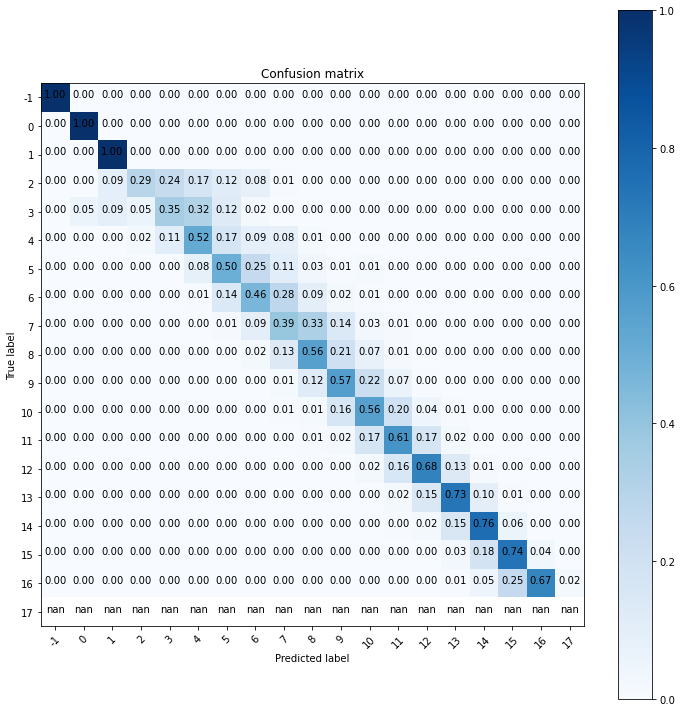

```python
cm = confusion_matrix(df_concat_r.result, np.round(prediction_r))
classes = range(-1,18)
plt.figure(figsize=(10,10))
plot_confusion_matrix(cm, classes,title='Confusion matrix')
```

```python
from sklearn.metrics import f1_score

f1_score(df_concat_r.result, np.round(prediction_r), average = "micro")
```

```
0.6906156117928611
```

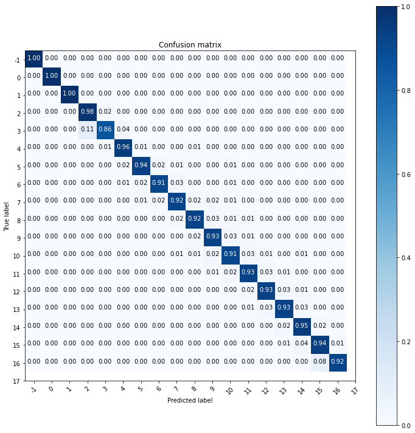

```python
cm = confusion_matrix(df_concat_c.result, np.round(prediction_c))
classes = range(-1,18)
plt.figure(figsize=(10,10))
plot_confusion_matrix(cm, classes,title='Confusion matrix')
```

```python
f1_score(df_concat_c.result, np.round(prediction_c), average = "micro")
```

```
0.9397117979530526
```

Widać, że model klasyfikujący daje dużo lepszy wynik, niż model regresyjny. Możliwym jest też, że jest on mocno przetrenowany, natomiast regresja powinna być na to bardziej odporna.